# 17. Dates, Datetimes, and Times

One of the topics we covered early on this course was the idea of a data type, which we defined as the type of data stored in the column of a tabular dataset. Most commonly these have been numbers (`<int>` or `<dbl>`) or character strings (`<chr>`). We’ve also common across the logical data type (`<lgl>`) , which can only be either `TRUE` or `FALSE`, and factors (`<fct>`). The latter are similar to character strings but have a built-in ordering of their unique values.

In these notes, we want to consider three new data types specifically designed to work with dates and times. With some reflection, it should seem reasonable to have specific data type for date and times because they act somewhat like a number (ordered, some meaning of distances), somewhat like a categorical variable (there are fixed values), and have some unique properties (such as issues with days of the week and timezones).

The three data types we will work with are:

- **date** (`<date>`) to represent a single day in time
- **datetime** (`<S3: POSIXct>`) to represent a particular time during a particular day
- **time** (`<S3: hms>`) to represent a time of day without reference to a specific day

The first two are far more common than the last. Let’s start by looking at a dataset with a date column and discuss unique functions for working with these dates. Then, we’ll see how to extend this to the datetime and time objects.

## Dates

As an example dataset, let’s look at a modified version of the shark data from the first exam. The data is the same, but now we have a specific `date` column describing the data of the shark attack. Notice that the `read_csv` function has done the conversion to a date format automatically for us.

```r
sharks <- read_csv("../data/shark_attacks_date.csv")
sharks
```

```
## # A tibble: 367 × 11
##    date       outcome     lon   lat shark_type  shark_length num_sharks
##    <date>     <chr>     <dbl> <dbl> <chr>              <dbl>      <dbl>
##  1 1945-02-07 injured    151. -34.0 wobbegong            1.3          1
##  2 1946-02-10 injured    116. -31.9 white shark          4.2          1
##  3 1946-08-18 fatal      146. -16.7 tiger shark          4.8          1
##  4 1947-12-21 injured    153. -31.7 bull shark           2            1
##  5 1948-02-12 fatal      152. -32.8 tiger shark          4            1
##  6 1949-01-13 uninjured  151. -33.7 white shark          3            1
##  7 1949-01-23 fatal      152. -32.9 white shark          4            1
##  8 1949-04-17 fatal      146. -16.7 tiger shark          3.6          1
##  9 1949-05-16 injured    122. -18.0 bull shark           2.7          1
## 10 1949-11-20 injured    151. -34   wobbegong            2            2
## # ℹ 357 more rows
## # ℹ 4 more variables: provoked <chr>, victim_activity <chr>, age <dbl>,
## #   gender <chr>
```

There are a number of specific functions that can be used inside the mutate function to extract elements of the date. For example, we can get the year, month, and day of the attack as new columns with the following:

```r
sharks |>
  mutate(
    year = year(date),
    month = month(date),
    day = day(date),
    wday = wday(date)
  ) |>
  select(date, year, month, day, wday)
```

```
## # A tibble: 367 × 5
##    date        year month   day  wday
##    <date>     <dbl> <dbl> <int> <dbl>
##  1 1945-02-07  1945     2     7     3
##  2 1946-02-10  1946     2    10     7
##  3 1946-08-18  1946     8    18     7
##  4 1947-12-21  1947    12    21     7
##  5 1948-02-12  1948     2    12     4
##  6 1949-01-13  1949     1    13     4
##  7 1949-01-23  1949     1    23     7
##  8 1949-04-17  1949     4    17     7
##  9 1949-05-16  1949     5    16     1
## 10 1949-11-20  1949    11    20     7
## # ℹ 357 more rows
```

Note that `month` and `wday` have options to return character strings rather than numbers, which can be useful:

```r
sharks |>
  mutate(
    month = month(date, label = TRUE, abbr = FALSE),
    wday = wday(date, label = TRUE, abbr = FALSE)
  ) |>
  select(date, month, wday)
```

```
## # A tibble: 367 × 3
##    date       month    wday
##    <date>     <ord>    <ord>
##  1 1945-02-07 February Wednesday
##  2 1946-02-10 February Sunday
##  3 1946-08-18 August   Sunday
##  4 1947-12-21 December Sunday
##  5 1948-02-12 February Thursday
##  6 1949-01-13 January  Thursday
##  7 1949-01-23 January  Sunday
##  8 1949-04-17 April    Sunday
##  9 1949-05-16 May      Monday
## 10 1949-11-20 November Sunday
## # ℹ 357 more rows
```

The character strings that come out of these two functions already have a built in ordering, which makes plots slightly easier to create (though not the comment regarding the line layer below). Here are the number of attacks per months in the `sharks` data:

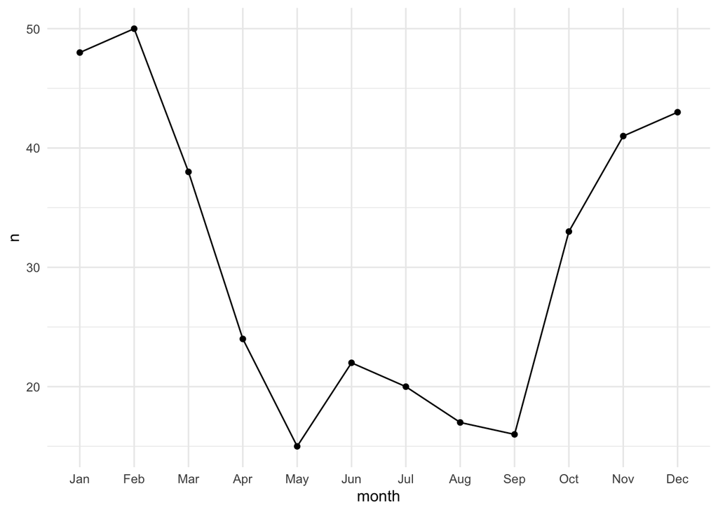

```r
sharks |>
  mutate(
    month = month(date, label = TRUE, abbr = TRUE),
  ) |>
  group_by(month) |>
  summarize(n = n()) |>
  ggplot(aes(month, n)) +
    geom_point() +
    geom_line(aes(group = 1))  # the group = 1 is needed to connect the dots
```

Using a date object as the x- or y-aesthetic in a plot works without an addition effort on our part. Here, we’ll plot just the attacks in 1990, with `date` on the x-axis.

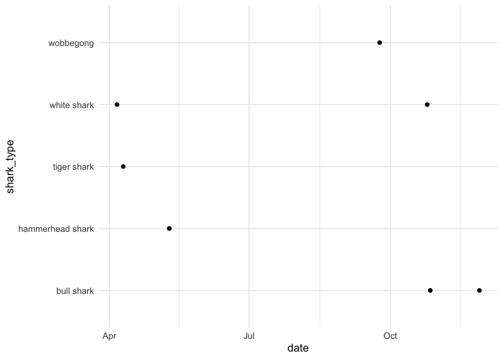

```r
sharks |>
  filter(year(date) %in% c(1990)) |>
  ggplot(aes(date, shark_type)) +
    geom_point()
```

Often with dates, it is useful to manually modify the labels on the time-based axis. We do this with `scale_x_date` (or its y-equivalent if time is on the y-axis). Adding this scale to a plot on its own will have no effect, but we can change the default by changing three parameters:

- `date_breaks` a string describing the frequency of the labels, such as “month” or “2 years”
- `date_minor_breaks` a string describing the frequency of the grid-lines
- `date_labels` format string: [strptime](https://rdrr.io/r/base/strptime.html)

You can set just a subset of these, depending on how much control you want over the plot. For example, let’s label the previous plot by showing a label for every month, and using the pattern “%B” to show (just) the full month’s name.

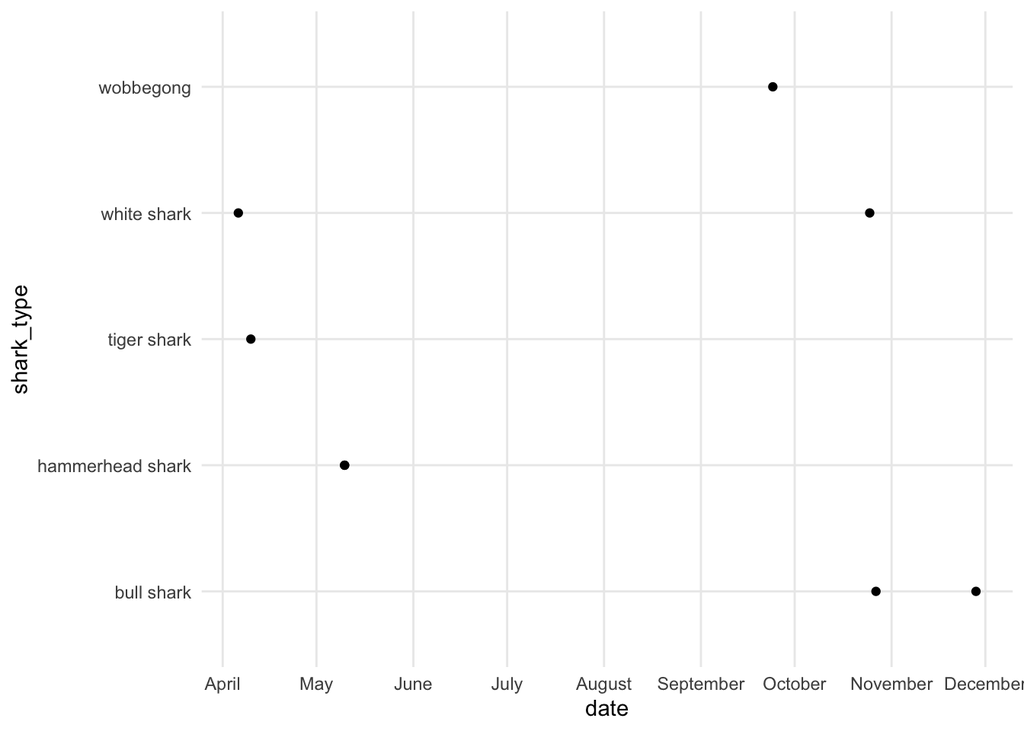

```r
sharks |>
  filter(year(date) %in% c(1990)) |>
  ggplot(aes(date, shark_type)) +
    geom_point() +
    scale_x_date(
      date_breaks = "month",
      date_labels = "%B",
      date_minor_breaks = "month"
    )
```

### Datetimes

To explore datetimes, let’s look at a version of the flights dataset, but this time from the three NYC airports. Reading the data into R shows that one of these columns, `time_hour` contains a special object for holding information about the time of the weather reading.

```r
weather <- read_csv("../data/flights_weather.csv")
weather
```

```
## # A tibble: 26,110 × 5
##    origin time_hour            temp wind_speed visib
##    <chr>  <dttm>              <dbl>      <dbl> <dbl>
##  1 EWR    2013-01-01 06:00:00  39.0      10.4     10
##  2 EWR    2013-01-01 07:00:00  39.0       8.06    10
##  3 EWR    2013-01-01 08:00:00  39.0      11.5     10
##  4 EWR    2013-01-01 09:00:00  39.9      12.7     10
##  5 EWR    2013-01-01 10:00:00  39.0      12.7     10
##  6 EWR    2013-01-01 11:00:00  37.9      11.5     10
##  7 EWR    2013-01-01 12:00:00  39.0      15.0     10
##  8 EWR    2013-01-01 13:00:00  39.9      10.4     10
##  9 EWR    2013-01-01 14:00:00  39.9      15.0     10
## 10 EWR    2013-01-01 15:00:00  41        13.8     10
## # ℹ 26,100 more rows
```

As with the date data type, we can use a variety of functions inside a mutate to extract information about the time. All of the same date functions exists as well as some extra ones specifically for time.

```r
weather |>
  mutate(month = month(time_hour), hour = hour(time_hour)) |>
  select(time_hour, month, hour)
```

```
## # A tibble: 26,110 × 3
##    time_hour           month  hour
##    <dttm>              <dbl> <int>
##  1 2013-01-01 06:00:00     1     6
##  2 2013-01-01 07:00:00     1     7
##  3 2013-01-01 08:00:00     1     8
##  4 2013-01-01 09:00:00     1     9
##  5 2013-01-01 10:00:00     1    10
##  6 2013-01-01 11:00:00     1    11
##  7 2013-01-01 12:00:00     1    12
##  8 2013-01-01 13:00:00     1    13
##  9 2013-01-01 14:00:00     1    14
## 10 2013-01-01 15:00:00     1    15
## # ℹ 26,100 more rows
```

Also, as with dates, we can set the time variable to the x- or y-aesthetic of a ggplot graphic and it will work as expected. Here is a plot showing the tempurature over the course of one day at JFK airport.

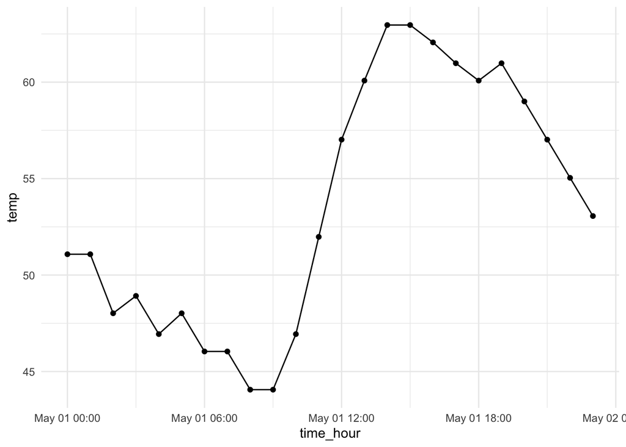

```r
weather |>
  filter(origin == "JFK") |>
  filter(year(time_hour) == 2013) |>
  filter(month(time_hour) == 5) |>
  filter(day(time_hour) == 1) |>
  ggplot(aes(time_hour, temp)) +
    geom_point() +
    geom_line()
```

We can modify the axis labels with `scale_x_datetime`. Note that this is a different function that required for dates, but the options are the same.

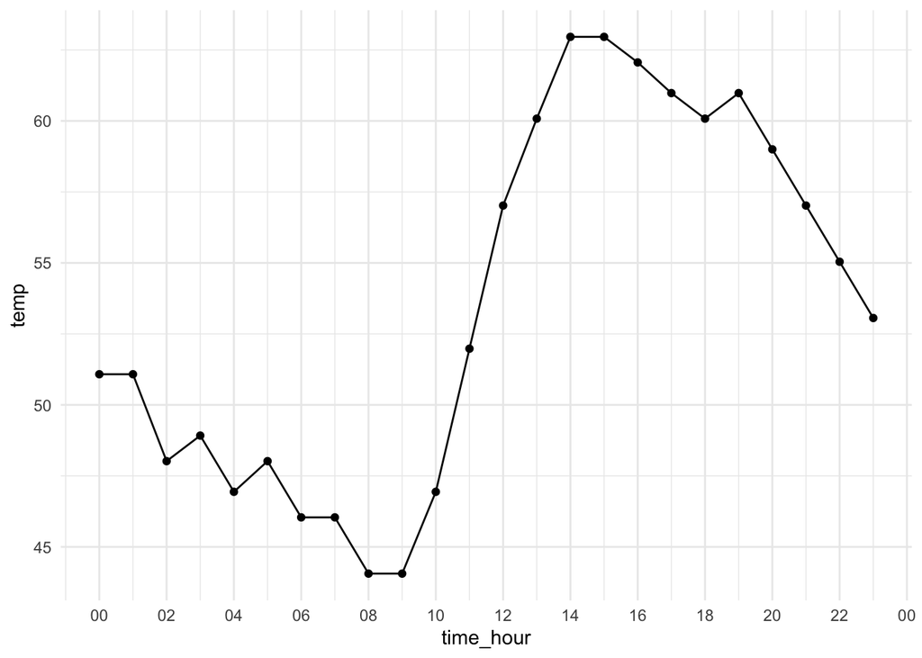

```r
weather |>
  filter(origin == "JFK") |>
  filter(year(time_hour) == 2013) |>
  filter(month(time_hour) == 5) |>
  filter(day(time_hour) == 1) |>
  ggplot(aes(time_hour, temp)) +
    geom_point() +
    geom_line()  +
    scale_x_datetime(
      date_breaks = "2 hours",
      date_labels = "%H"
    )
```

Here’s another example showing how to label the axis with the days of the week and how to select a week of the year using the `isoweek` function:

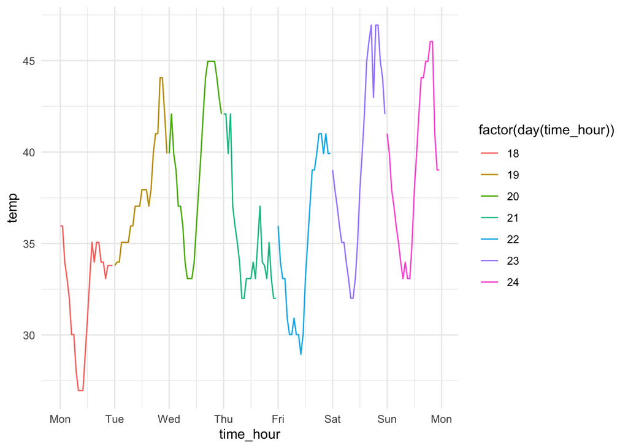

```r
weather |>
  filter(origin == "JFK") |>
  filter(year(time_hour) == 2013) |>
  filter(isoweek(time_hour) == 12) |>
  ggplot(aes(time_hour, temp)) +
    geom_line(aes(color = factor(day(time_hour))))  +
    scale_x_datetime(
      date_breaks = "1 day",
      date_labels = "%a"
    )
```

### Time and Conversion

We can convert any datetime object to a date object or time object using the functions `as_date` and `as_hms`. For example:

```r
weather |>
  mutate(time_date = as_date(time_hour), time = as_hms(time_hour)) |>
  select(time_hour, time_date, time)
```

```
## # A tibble: 26,110 × 3
##    time_hour           time_date  time
##    <dttm>              <date>     <time>
##  1 2013-01-01 06:00:00 2013-01-01 06:00
##  2 2013-01-01 07:00:00 2013-01-01 07:00
##  3 2013-01-01 08:00:00 2013-01-01 08:00
##  4 2013-01-01 09:00:00 2013-01-01 09:00
##  5 2013-01-01 10:00:00 2013-01-01 10:00
##  6 2013-01-01 11:00:00 2013-01-01 11:00
##  7 2013-01-01 12:00:00 2013-01-01 12:00
##  8 2013-01-01 13:00:00 2013-01-01 13:00
##  9 2013-01-01 14:00:00 2013-01-01 14:00
## 10 2013-01-01 15:00:00 2013-01-01 15:00
## # ℹ 26,100 more rows
```

The function `ymd` will create a date object from a string. Putting this together with the `as_date` function, we can simplify the code we used to select a particular day of the year:

```r
weather |>
  filter(as_date(time_hour) == ymd("2013-05-01"))
```

```
## # A tibble: 72 × 5
##    origin time_hour            temp wind_speed visib
##    <chr>  <dttm>              <dbl>      <dbl> <dbl>
##  1 EWR    2013-05-01 00:00:00  57.0       4.60    10
##  2 EWR    2013-05-01 01:00:00  55.9       3.45    10
##  3 EWR    2013-05-01 02:00:00  55.0       3.45    10
##  4 EWR    2013-05-01 03:00:00  54.0       0       10
##  5 EWR    2013-05-01 04:00:00  52.0       0       10
##  6 EWR    2013-05-01 05:00:00  53.1       0       10
##  7 EWR    2013-05-01 06:00:00  48.9       3.45    10
##  8 EWR    2013-05-01 07:00:00  45.0       6.90    10
##  9 EWR    2013-05-01 08:00:00  46.0       8.06    10
## 10 EWR    2013-05-01 09:00:00  44.1       6.90    10
## # ℹ 62 more rows
```

While it is rare to deal with time data without dates in the original data, this comes up frequently when working with certain kinds of analysis. For example, here we can use the `as_hms` function to show the daily tempurature changes over the course of a week:

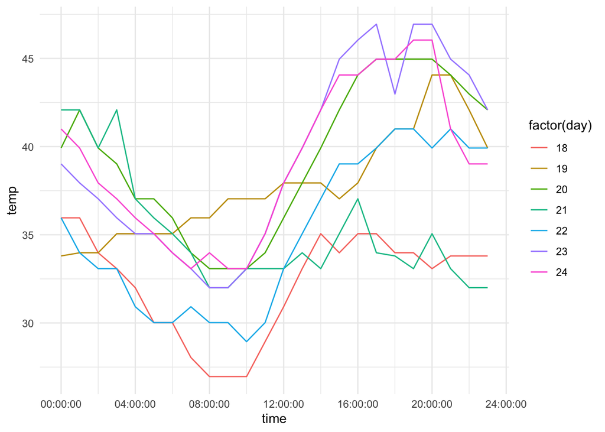

```r
weather |>
  filter(origin == "JFK") |>
  filter(year(time_hour) == 2013) |>
  filter(isoweek(time_hour) == 12) |>
  mutate(time = as_hms(time_hour)) |>
  mutate(day = day(time_hour)) |>
  ggplot(aes(time, temp)) +
    geom_line(aes(color = factor(day)))
```

The functionality for time objects is not as good as for date and datetime objects, so try to make use of the latter two whenever possible.

### Homework

The canonical and best way to store a date object inside of a CSV file is to format the date as “YYYY-MM-DD”. Datetimes can be similarly stored in the format “YYYY-MM-DD HH:MM” or “YYYY-MM-DD HH:MM:SS” and times as “HH:MM” or “HH:MM:SS”. Write down on a piece of paper the following information in the appropriate format.

1. When you woke up this morning.
2. The first day of this semester.
3. When you were born.
4. When you’re alarm is currently set for.
5. The date of your next birthday.